# Margin of Error - Analytical Approximations

Jeff Sunil

# Introduction

The [Earth Impacts Program](https://impact.ese.ic.ac.uk/ImpactEarth/ImpactEffects/) is a program that simulates the crashing of an asteroid into our planet and provides information calculated from it. It is based around inputs received from the user, such as diameter, density and velocity of the asteroid.

However, some of the formulas used for the program are analytical approximations: generated from analyzing previous data. This report aims to evaluate the effectiveness of these formulas against the pure mathematical alternatives.

# Methodology

Here, we examine the formula for calculating z*, an important constant that is further used to calculate the altitude at which an asteroid will burst into fragments, if it will at all.

Note that we define the following variables used in the code. Note that these are meant to be examples on which the code is based on. Units are very important:

- Diameter: 750 m
- Density: 1000 kg/m<sup>3</sup>
- Velocity: 11 km/s

## Formulas

### Pure Math

Here we analyse the true mathematical formula required. The formula is based on two functions:

- The rho function, which calculates density of the atmosphere given altitude

```r
rho <- function(z){
  density * exp(-z / 8000)
}
```

- The v function, which calculates the velocity of the asteroid depending on altitude

```r
v <- function (z) {
  velocity * exp((-3 * rho(z) * 2 * 8000) / (4 * density * diameter * sqrt(2) / 2))
}
```

We also need to calculate the yield strength (yI), which is a measure of the pressure needed to break the asteroid.

```r
yI <- 10 ^ (2.107 + (0.0624 * sqrt(density)))
```

From this, the altitude z* follows the relationship $Y_i = \rho(z_*)v^2(z_*)$. The math needed to solve this equation is very complex, and so, it is not detailed here.

### Approximation

The approximation used by the program is defined in relation to iF, another constant which is defined here as well:

```r
iF <- (4.07 * 2 * 8000 * yI) / (density * diameter * (velocity ^ 2) * sqrt(2) / 2)
zStarApprox <- -8000 * (log(yI / (velocity ^ 2)) + 1.308 - (0.314 * iF) - (1.303 * sqrt(1 - iF)))
```

## Calculations

Here, we show a smooth density plot to visualize the proportional difference between the true mathematical formula and the approximation.

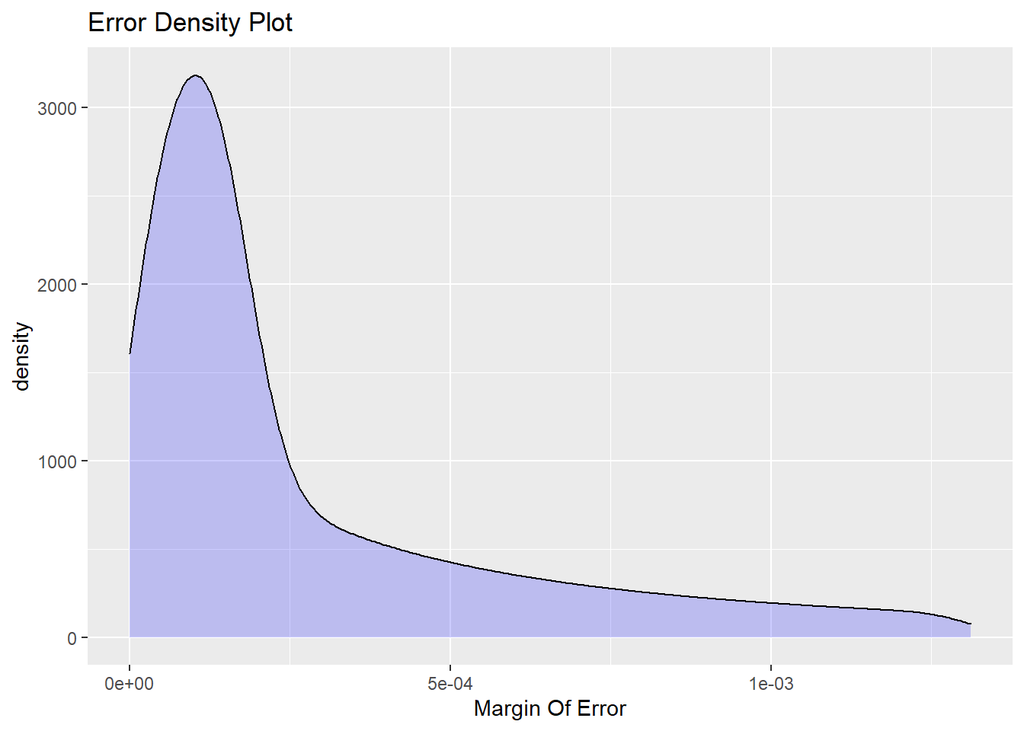

```r
df <- data.frame(Diameter = n, Error = s_n)

densityPlot <- df %>% ggplot(aes(Error)) +
  geom_density(fill="blue", alpha=0.2) +
  xlab("Margin Of Error") +
  ggtitle("Error Density Plot")

densityPlot
```

# Conclusions

The margin of error is very often below 0.1% (1e-03) of the actual value, which is much below the value required for statistical significance, 5%. Therefore, the analytical approximations used by the program are indeed excellent and do not make a noticeable impact on any of the figures produced from the program.